# Project Foundations for Data Science: FoodHub Data Analysis

**Marks: 60**

### Context

The number of restaurants in New York is increasing day by day. Lots of students and busy professionals rely on those restaurants due to their hectic lifestyles. Online food delivery service is a great option for them. It provides them with good food from their favorite restaurants. A food aggregator company FoodHub offers access to multiple restaurants through a single smartphone app.

The app allows the restaurants to receive a direct online order from a customer. The app assigns a delivery person from the company to pick up the order after it is confirmed by the restaurant. The delivery person then uses the map to reach the restaurant and waits for the food package. Once the food package is handed over to the delivery person, he/she confirms the pick-up in the app and travels to the customer's location to deliver the food. The delivery person confirms the drop-off in the app after delivering the food package to the customer. The customer can rate the order in the app. The food aggregator earns money by collecting a fixed margin of the delivery order from the restaurants.

### Objective

The food aggregator company has stored the data of the different orders made by the registered customers in their online portal. They want to analyze the data to get a fair idea about the demand of different restaurants which will help them in enhancing their customer experience. Suppose you are hired as a Data Scientist in this company and the Data Science team has shared some of the key questions that need to be answered. Perform the data analysis to find answers to these questions that will help the company to improve the business.

### Data Description

The data contains the different data related to a food order. The detailed data dictionary is given below.

### Data Dictionary

- order_id: Unique ID of the order
- customer_id: ID of the customer who ordered the food
- restaurant_name: Name of the restaurant
- cuisine_type: Cuisine ordered by the customer
- cost: Cost of the order
- day_of_the_week: Indicates whether the order is placed on a weekday or weekend (The weekday is from Monday to Friday and the weekend is Saturday and Sunday)
- rating: Rating given by the customer out of 5
- food_preparation_time: Time (in minutes) taken by the restaurant to prepare the food. This is calculated by taking the difference between the timestamps of the restaurant's order confirmation and the delivery person's pick-up confirmation.
- delivery_time: Time (in minutes) taken by the delivery person to deliver the food package. This is calculated by taking the difference between the timestamps of the delivery person's pick-up confirmation and drop-off information

### Let us start by importing the required libraries

```python
# import libraries for data manipulation
import numpy as np
import pandas as pd

# import libraries for data visualization
import matplotlib.pyplot as plt
import seaborn as sns
```

```python
from google.colab import drive
drive.mount('/content/drive')
```

### Understanding the structure of the data

```python
# read the data
data = pd.read_csv('/content/drive/MyDrive/Colab Notebooks/Projects/FoodHub/foodhub_order.csv')

# Copying data to another variable to avoid any changes to the original data
df = data.copy()

# returns the first 5 rows
df.head()
```

|  | order_id | customer_id | restaurant_name | cuisine_type | cost_of_the_order | day_of_the_week | rating | food_preparation_time | delivery_time |
| --- | --- | --- | --- | --- | --- | --- | --- | --- | --- |
| 0 | 1477147 | 337525 | Hangawi | Korean | 30.75 | Weekend | Not given | 25 | 20 |
| 1 | 1477685 | 358141 | Blue Ribbon Sushi Izakaya | Japanese | 12.08 | Weekend | Not given | 25 | 23 |
| 2 | 1477070 | 66393 | Cafe Habana | Mexican | 12.23 | Weekday | 5 | 23 | 28 |
| 3 | 1477334 | 106968 | Blue Ribbon Fried Chicken | American | 29.20 | Weekend | 3 | 25 | 15 |
| 4 | 1478249 | 76942 | Dirty Bird to Go | American | 11.59 | Weekday | 4 | 25 | 24 |

#### Observations:

The DataFrame has 9 columns as mentioned in the Data Dictionary. Data in each row corresponds to the order placed by a customer.

### **Question 1:** How many rows and columns are present in the data? [0.5 mark]

```python
df.shape # Write your code here
```

```
(1898, 9)
```

#### Observations: there are 1898 rows and 9 columns of data

### **Question 2:** What are the datatypes of the different columns in the dataset? (The info() function can be used) [0.5 mark]

```python
df.info() # Use info() to print a concise summary of the DataFrame
```

```
<class 'pandas.core.frame.DataFrame'>
RangeIndex: 1898 entries, 0 to 1897
Data columns (total 9 columns):
 #   Column                 Non-Null Count  Dtype
---  ------                 --------------  -----
 0   order_id               1898 non-null   int64
 1   customer_id            1898 non-null   int64
 2   restaurant_name        1898 non-null   object
 3   cuisine_type           1898 non-null   object
 4   cost_of_the_order      1898 non-null   float64
 5   day_of_the_week        1898 non-null   object
 6   rating                 1898 non-null   object
 7   food_preparation_time  1898 non-null   int64
 8   delivery_time          1898 non-null   int64
dtypes: float64(1), int64(4), object(4)
memory usage: 133.6+ KB
```

#### Observations:

there are 3 data types present in the dataset:

- order_id, customer_id, food_preparation_time, and delivery_time are integers
- cost_of_the_order is a float
- restaurant_name, cuisine_type, day_of_the_week, and rating are objects

There are no null observations within each variable

restaurant_name, cuisine_type, and day_of_the_week should be categorical variables

rating should be an integer because we may want to perform arithmetic or statistical operations on it (e.g. average)

although the order_id and customer_id variables are stored as integers in the pandas dataframe, i would prefer to store these unique identifiers as strings because I do not want to perform mathematical operations on these variables:

```python
# Convert restaurant_name, cuisine_type, and day_of_the_week to categorical variables
#df['restaurant_name'] = df['restaurant_name'].astype('category')
#df['cuisine_type'] = df['cuisine_type'].astype('category')
#df['day_of_the_week'] = df['day_of_the_week'].astype('category')

# Convert order_id and customer_id to string variables
df['order_id'] = df['order_id'].astype(str)
df['customer_id'] = df['customer_id'].astype(str)
```

### **Question 3:** Are there any missing values in the data? If yes, treat them using an appropriate method. [1 mark]

```python
null_values = df.isnull().sum() # Check for null values in each column
print(f"Columns with Null Values:{null_values}") # Print the columns with null values and their counts
```

```
Columns with Null Values:order_id                 0
customer_id              0
restaurant_name          0
cuisine_type             0
cost_of_the_order        0
day_of_the_week          0
rating                   0
food_preparation_time    0
delivery_time            0
dtype: int64
```

#### Observations: There are no null values in any column.

### **Question 4:** Check the statistical summary of the data. What is the minimum, average, and maximum time it takes for food to be prepared once an order is placed? [2 marks]

```python
#create another copy of the original dataframe so that changes dont percolate to the original dataset
df_copy = df.copy()

#Statistical summary of the numeric columns rounded to 2 decimal places
summary_numeric = df_copy.describe().apply(lambda x: round(x, 2)).T
print(summary_numeric)
```

```
                        count   mean   std    min    25%    50%   75%    max
cost_of_the_order      1898.0  16.50  7.48   4.47  12.08  14.14  22.3  35.41
food_preparation_time  1898.0  27.37  4.63  20.00  23.00  27.00  31.0  35.00
delivery_time          1898.0  24.16  4.97  15.00  20.00  25.00  28.0  33.00
```

```python
#Statistical summary of the non-numeric columns
summary_categorical = df.describe(exclude='number').T
print(summary_categorical)
```

```
                count unique          top  freq
order_id         1898   1898      1477147     1
customer_id      1898   1200        52832    13
restaurant_name  1898    178  Shake Shack   219
cuisine_type     1898     14     American   584
day_of_the_week  1898      2      Weekend  1351
rating           1898      4    Not given   736
```

#### Observations:

- there are a total of 178 restaurants
- shake shack is the most popular restaurant and American cuisine is ordered most often
- there are 736 orders that are not rated

Food Preparation times:

- min - 20 minutes
- average - 27 minutes and 22 seconds
- max - 35 minutes

```python
minutes_float = 24.161749

# Define a function to convert minutes to minutes and seconds
def convert_minutes_to_minutes_seconds(minutes_float):
    # Extract the integer part (minutes)
    minutes = int(minutes_float)

    # Calculate the remaining seconds
    seconds = (minutes_float - minutes) * 60

    return minutes, seconds

# Call the function and print the result
result_minutes, result_seconds = convert_minutes_to_minutes_seconds(minutes_float)
print(f"{result_minutes} minutes {result_seconds:.2f} seconds")
```

```
24 minutes 9.70 seconds
```

### **Question 5:** How many orders are not rated? [1 mark]

```python
df['rating'].value_counts()   # Write the code here
```

```
Not given    736
5            588
4            386
3            188
Name: rating, dtype: int64
```

```python
# Count the number of orders where 'rating' is 'Not given'
unrated_orders = df[df['rating'] == 'Not given']
num_unrated_orders = len(unrated_orders)

print(f"Number of unrated orders: {num_unrated_orders}")
```

```
Number of unrated orders: 736
```

```python
# Looking at the distribution of observations across the rating variable
df['rating'].value_counts(normalize = True)
```

```
Not given    0.387777
5            0.309800
4            0.203372
3            0.099052
Name: rating, dtype: float64
```

#### Observations:

736 of 1898 orders were not given a rating, this represents almost 40% of all orders

### Exploratory Data Analysis (EDA)

### **Question 6:** Explore all the variables and provide observations on their distributions. (Generally, histograms, boxplots, countplots, etc. are used for univariate exploration.) [9 marks]

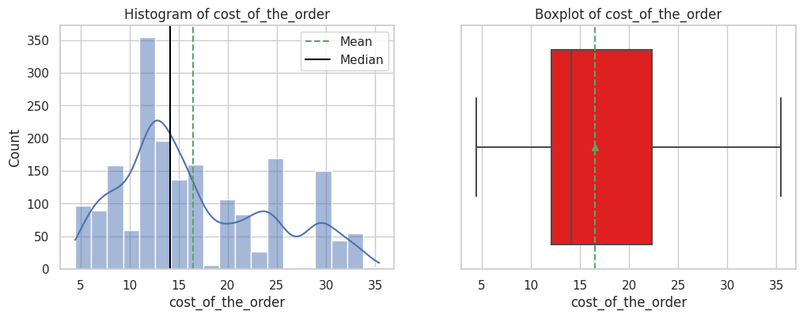

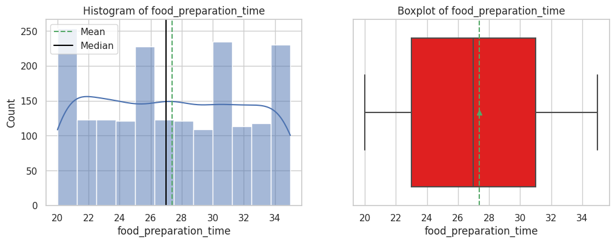

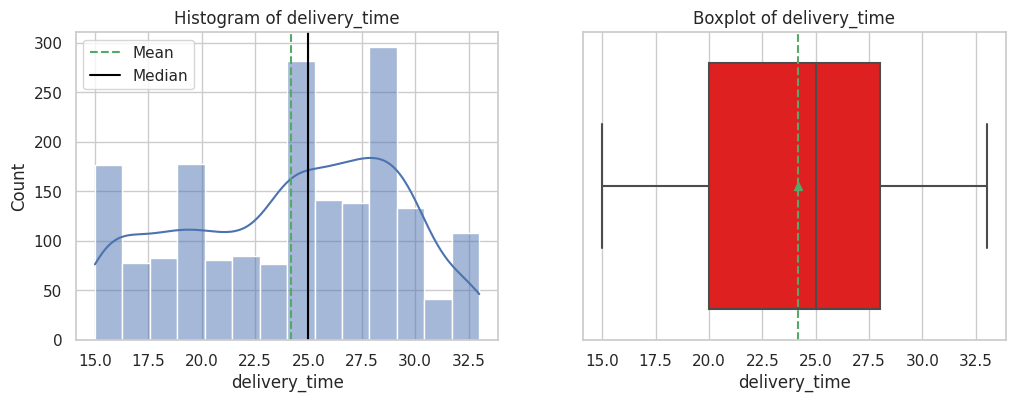

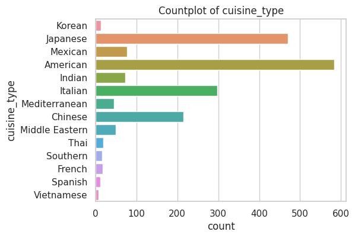

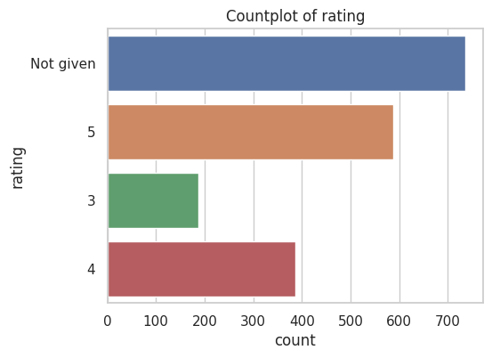

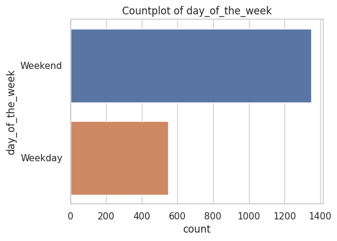

```python
# Set the style for Seaborn plots
sns.set(style="whitegrid")

# Define a function to plot histograms, boxplots, and countplots
def univariate_eda(column_name):
    plt.figure(figsize=(12, 4))

 # Countplot (for categorical variables)
    if df[column_name].dtype == 'object':
        plt.subplot(1, 2, 1)
        sns.countplot(data=df, y=column_name)
        plt.title(f'Countplot of {column_name}')

    else:
      # Histogram
      plt.subplot(1, 2, 1)
      sns.histplot(data=df, x=column_name, bins="auto", kde=True)
      plt.axvline(np.mean(df[column_name]), color='g', linestyle='--', label='Mean')
      plt.axvline(np.median(df[column_name]), color='black', linestyle='-', label='Median')
      plt.legend()
      plt.title(f'Histogram of {column_name}')

      # Boxplot
      plt.subplot(1, 2, 2)
      sns.boxplot(data=df, x=column_name, showmeans=True, color='red')
      plt.axvline(np.mean(df[column_name]), color='g', linestyle='--', label='Mean')
      plt.title(f'Boxplot of {column_name}')


    plt.show()

# List of columns you want to explore
columns_to_explore = ['cost_of_the_order', 'food_preparation_time', 'delivery_time', 'cuisine_type', 'rating', 'day_of_the_week']

# Perform univariate EDA for each selected column
for column in columns_to_explore:
    univariate_eda(column)
```

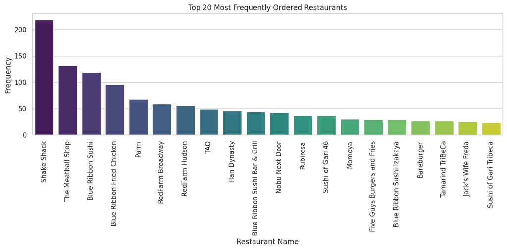

```python
# Get the 20 most frequently ordered restaurants
top_restaurants = df['restaurant_name'].value_counts().head(20)

# Create a countplot
plt.figure(figsize=(12, 6))
sns.countplot(data=df[df['restaurant_name'].isin(top_restaurants.index)], #.index to extract the labels (restaurant names) from the top_restaurants Series. It helps set the order of the bars in the countplot to match the frequency ranking of the restaurants.
              x='restaurant_name',
              order=top_restaurants.index,
              palette='viridis')

plt.xticks(rotation=90)
plt.title('Top 20 Most Frequently Ordered Restaurants')
plt.xlabel('Restaurant Name')
plt.ylabel('Frequency')
plt.tight_layout()
plt.show()
```

```python
unique_restaurants = df['restaurant_name'].unique()

len(unique_restaurants)
```

```
178
```

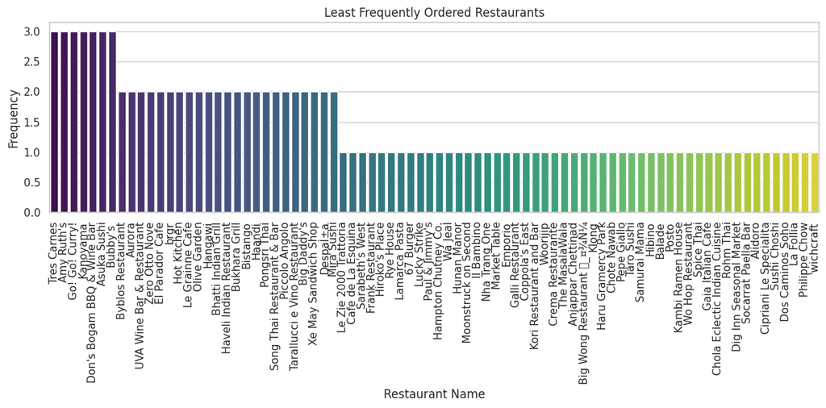

```python
# Get the least frequently ordered restaurants
bottom_restaurants = df['restaurant_name'].value_counts().tail(80)

# Create a countplot
plt.figure(figsize=(12, 6))
sns.countplot(data=df[df['restaurant_name'].isin(bottom_restaurants.index)],
              x='restaurant_name',
              order=bottom_restaurants.index,
              palette='viridis')  # You can choose a different color palette

plt.xticks(rotation=90)
plt.title('Least Frequently Ordered Restaurants')
plt.xlabel('Restaurant Name')
plt.ylabel('Frequency')
plt.tight_layout()
plt.show()
```

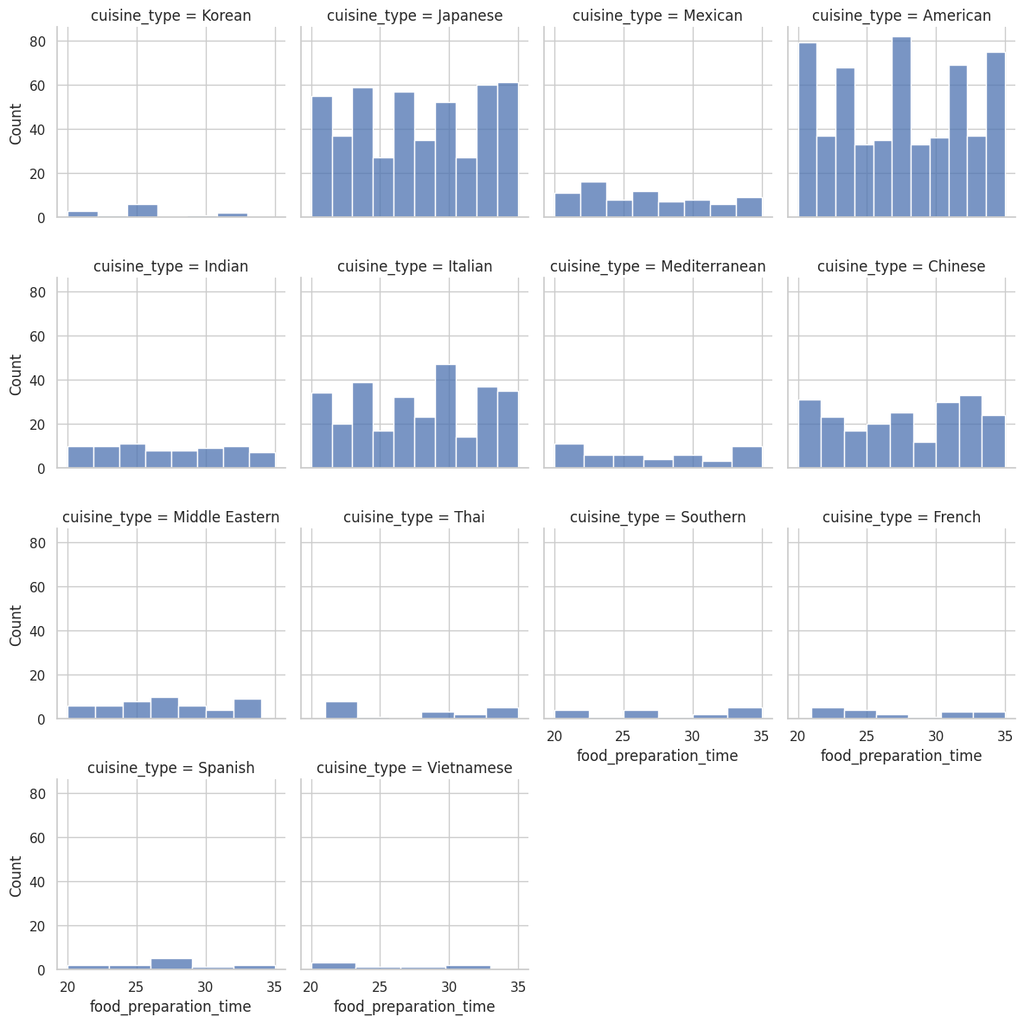

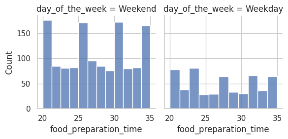

```python
# subplots to compare the distribution of food_preparation_time for each value of cuisine_type
g = sns.FacetGrid(df, col='cuisine_type', col_wrap=4)
g.map(sns.histplot, "food_preparation_time")

# subplots to compare the distribution of food_preparation_time for weekdays vs weekends
g = sns.FacetGrid(df, col='day_of_the_week')
g.map(sns.histplot, "food_preparation_time")
```

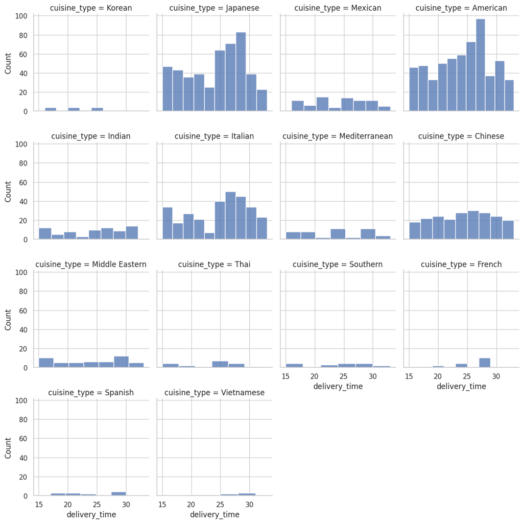

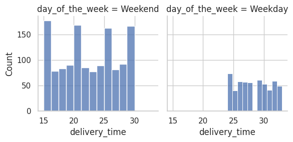

```python
# subplots to compare the distribution of delivery_time for each value of cuisine_type
g = sns.FacetGrid(df, col='cuisine_type', col_wrap=4)
g.map(sns.histplot, "delivery_time")

# subplots to compare the distribution of delivery_time for weekdays vs weekends
g = sns.FacetGrid(df, col='day_of_the_week')
g.map(sns.histplot, "delivery_time")
```

### **Question 7**: Which are the top 5 restaurants in terms of the number of orders received? [1 mark]

```python
# Use the 'value_counts()' function to count the orders for each restaurant
restaurant_counts = df['restaurant_name'].value_counts().head()

# Convert the result to a DataFrame for a more structured table
top_5 = pd.DataFrame({'Restaurant Name': restaurant_counts.index,
                                'Number of Orders': restaurant_counts.values})

# Print the frequency table
print(top_5)
```

```
             Restaurant Name  Number of Orders
0                Shake Shack               219
1          The Meatball Shop               132
2          Blue Ribbon Sushi               119
3  Blue Ribbon Fried Chicken                96
4                       Parm                68
```

#### Observations: the top 5 restaurants in terms of the number of orders received are:

- shake shack
- the meatball shop
- blue ribbon sushi
- blue ribbon fried chicken
- parm

### **Question 8**: Which is the most popular cuisine on weekends? [1 mark]

```python
# Filter the DataFrame to include only rows where day_of_the_week is 'Weekend'
weekend_orders = df[df['day_of_the_week'] == 'Weekend']

# Use the 'value_counts()' function to count the orders for each restaurant
weekend_cuisine_orders = weekend_orders['cuisine_type'].value_counts()

# Convert the result to a DataFrame for a more structured table
cuisine_wkend = pd.DataFrame({'Cuisine Type': weekend_cuisine_orders.index,
                                'Number of Orders': weekend_cuisine_orders.values})

most_popular_cuisine_weekend = cuisine_wkend.loc[cuisine_wkend['Number of Orders'].idxmax()]

print(most_popular_cuisine_weekend)
```

```
Cuisine Type        American
Number of Orders         415
Name: 0, dtype: object
```

#### Observations: American Cuisine is the most popular cuisine type on weekends, with a total of 415 orders

### **Question 9**: What percentage of the orders cost more than 20 dollars? [2 marks]

```python
# Filter orders with cost greater than $20
expensive_orders = df[df['cost_of_the_order'] > 20]

# Calculate the percentage
percentage_expensive_orders = (len(expensive_orders) / len(df)) * 100

print(f"Percentage of orders costing more than $20: {percentage_expensive_orders:.2f}%")
```

```
Percentage of orders costing more than $20: 29.24%
```

#### Observations:

- 29.24% of orders cost more than $20, which represents 555 orders

### **Question 10**: What is the mean order delivery time? [1 mark]

```python
mean_delivery = df['delivery_time'].mean()

print('the average delivery time for all orders is' ' {:2f}'.format(mean_delivery))
```

```
the average delivery time for all orders is 24.161749
```

#### Observations:

- the average delivery time for all orders is 24.161749, or 24 minutes and 9 seconds

### **Question 11:** The company has decided to give 20% discount vouchers to the top 3 most frequent customers. Find the IDs of these customers and the number of orders they placed. [1 mark]

```python
# Use the 'value_counts()' function to count the orders for each customer
top_3_customer_id = df['customer_id'].value_counts().head(3)

# Convert the result to a DataFrame for a more structured table
top_3_cust = pd.DataFrame({'Customer ID': top_3_customer_id.index,
                                'Number of Orders': top_3_customer_id.values})

# Print the frequency table
print(top_3_cust)
```

```
  Customer ID  Number of Orders
0       52832                13
1       47440                10
2       83287                 9
```

#### Observations:

- customer ID# 52832, 47440, and 83287 are the 3 most frequent customers with a total of 13, 10, and 9 orders respectively

### **Question 12**: Perform a multivariate analysis to explore relationships between the important variables in the dataset. (It is a good idea to explore relations between numerical variables as well as relations between numerical and categorical variables) [10 marks]

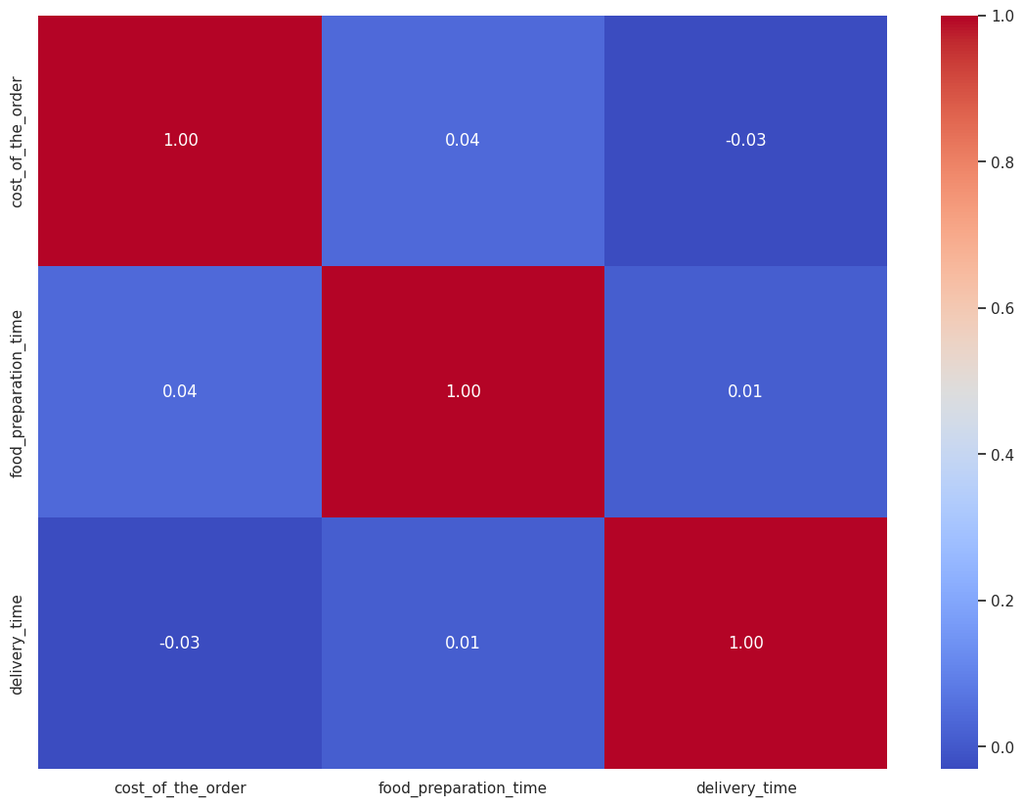

```python
# Check for correlation among numerical variables
num_var = ['cost_of_the_order', 'food_preparation_time','delivery_time']
corr = df[num_var].corr()

# Plot the heatmap
plt.figure(figsize = (14, 10))
sns.heatmap(corr, annot = True, cmap = 'coolwarm',
        fmt = ".2f",
        xticklabels = corr.columns,
        yticklabels = corr.columns)
```

Observations:

- there is a very weak positive correlation between food_preparation_time and delivery_time
- there is a very weak positive correlation between food_preparation_time and cost_of_the_order
- there is a very weak negative correlation between delivery_time and cost_of_the_order

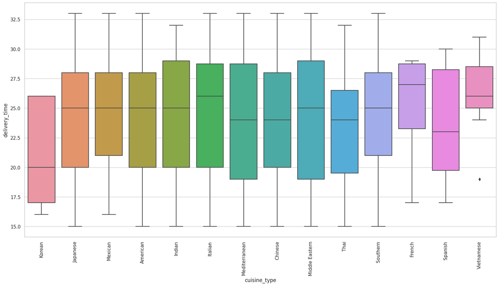

```python
 # Graph boxplots to show the distribution of delivery_time for each cuisine to understand how cuisine types influence the distribution of delivery times
plt.figure(figsize = (20, 10))
sns.boxplot(df, x='cuisine_type', y='delivery_time')
plt.xticks(rotation=90)
plt.show()
```

Observations:

- recall that the distribution of the delivery_time variable is slightly left-skewed
- The shape of the distribution seems to be influenced by cuisine_type.
  - In particular, Japanese, American, Italian, Thai, and French cuisine are all left skewed and since Japanese, American, Italian, and Chinese are the most frequently ordered cuisines, their influence on the overall shape of the delivery_time distribution is substantial.

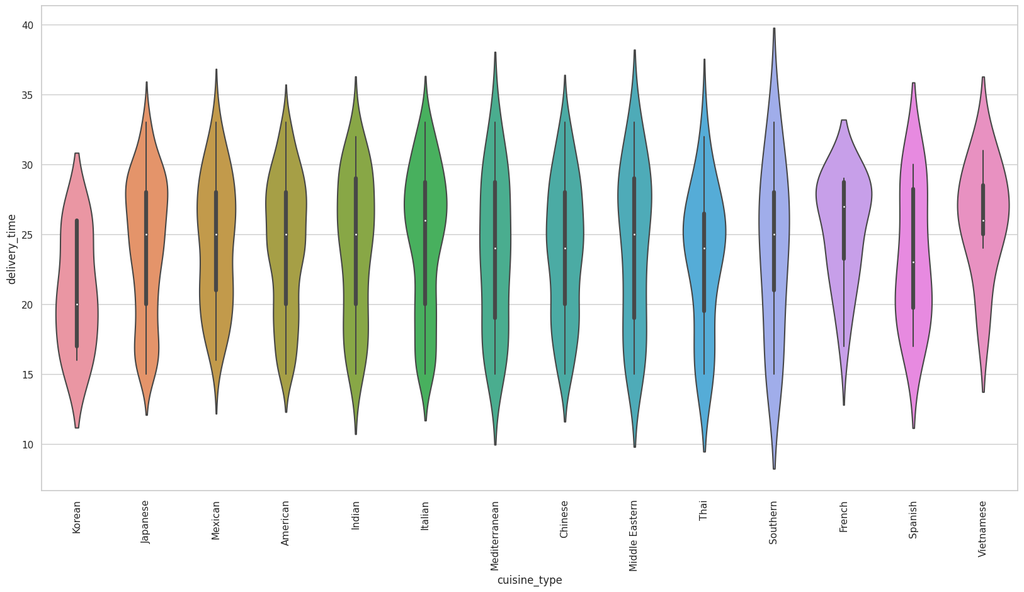

```python
plt.figure(figsize = (20, 10))
sns.violinplot(df, x='cuisine_type', y='delivery_time')
plt.xticks(rotation=90)
plt.show()
```

Observations:

- there is a higher probability that the delivery time for Japanese, Italian, French, and Vietnamese cuisine will exceed approximately 25 minutes
- The delivery time for Mediterranean, chinese, and southern cuisine is fairly evenly distributed (all delivery times within the range are equally probable when ordering there cuisines)

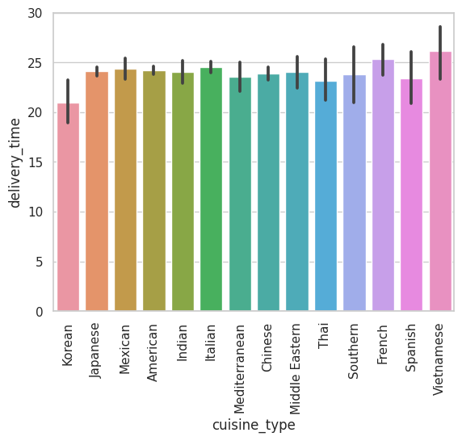

```python
sns.barplot(df, x='cuisine_type', y='delivery_time')
plt.xticks(rotation=90)
plt.show()
```

Observations:

- vietnamese and french cuisine have the longest delivery time on average
- Korean food has the shortest delivery time on average

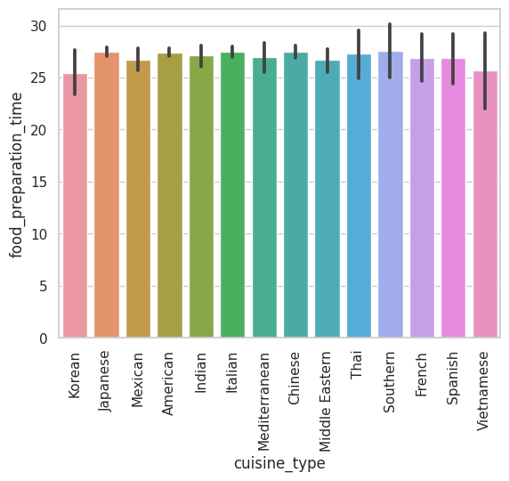

```python
sns.barplot(df, x='cuisine_type', y='food_preparation_time')
plt.xticks(rotation=90)
plt.show()
```

Observations:

- food preparation time for most cuisines is between approx. 25 and 28 minutes

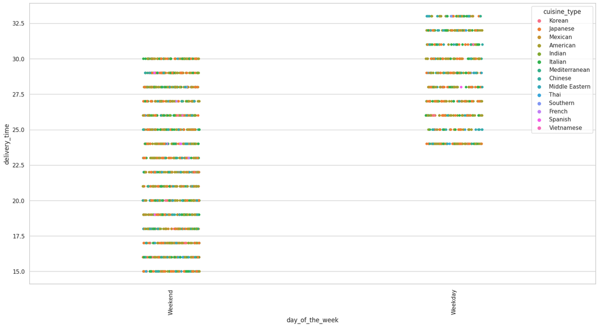

```python
plt.figure(figsize = (20, 10))
sns.stripplot(df, x='day_of_the_week', y='delivery_time', hue='cuisine_type', jitter=True)
plt.xticks(rotation=90)
plt.show()
```

Observations:

- delivery time on weekdays is longer on average than weekends

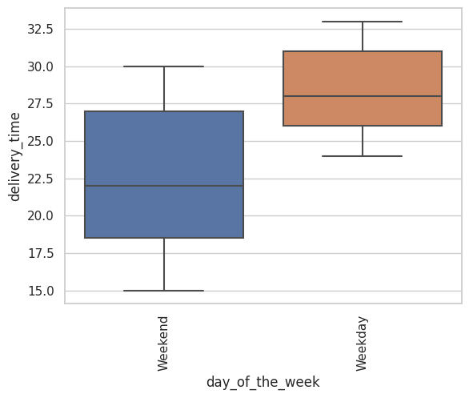

```python
# Graph boxplots to show the distribution of delivery_time for each cuisine to understand how cuisine types influence the distribution of delivery times
sns.boxplot(df, x='day_of_the_week', y='delivery_time')
plt.xticks(rotation=90)
plt.show()
```

Observations:

- Delivery times on weekdays are longer on average on compared to delivery times on weekends.
- there is a larger range of delivery times over weekends compared to weekdays

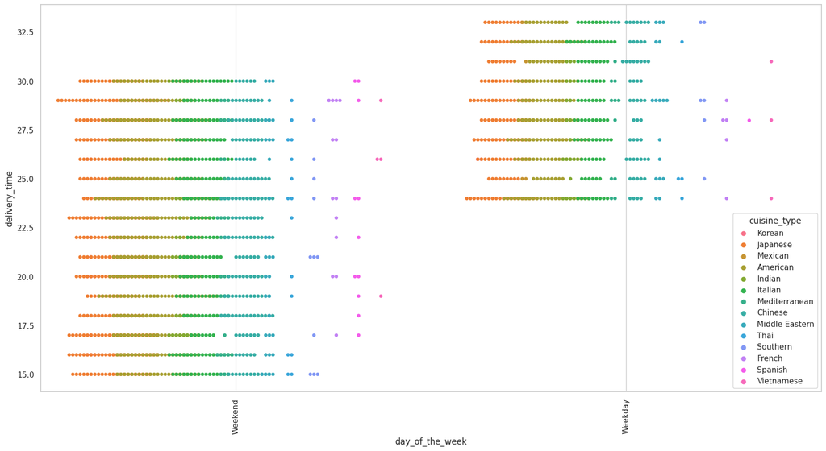

```python
plt.figure(figsize = (20, 10))
sns.swarmplot(df, x='day_of_the_week', y='delivery_time', hue='cuisine_type', dodge=True)
plt.xticks(rotation=90)
plt.grid()
plt.show()
```

Observations:

- observations for delivery time over the weekend is fairly evenly distributed between 15 and ~ 30 minutes
- observations for delivery time during the week is fairly evenly distributed between the ranges of ~24 to ~32 minutes

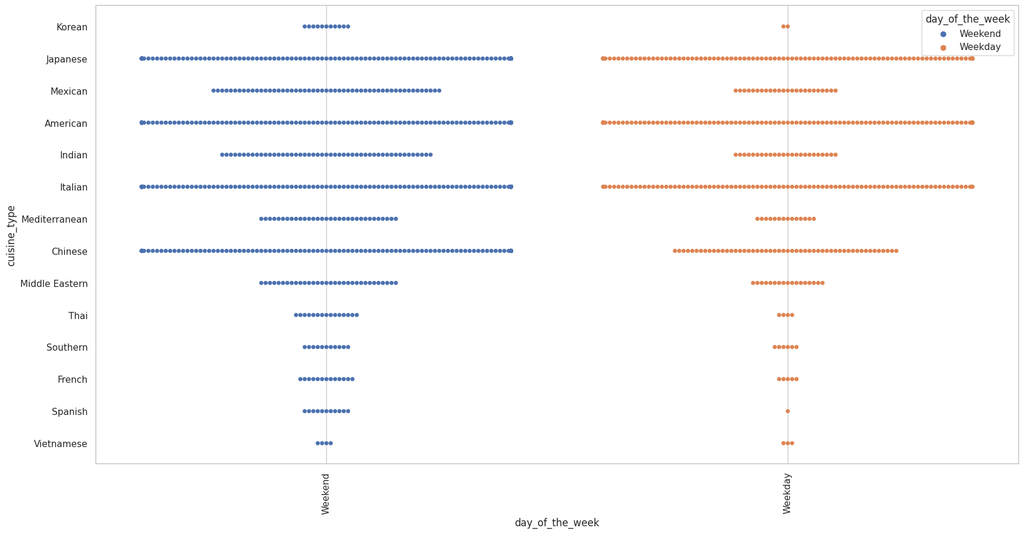

```python
plt.figure(figsize = (20, 10))
sns.swarmplot(df, x='day_of_the_week', y='cuisine_type', hue='day_of_the_week')
plt.xticks(rotation=90)
plt.grid()
plt.show()
```

Observations:

- generally, more orders are received on weekends than on weekdays
- There is a particularly large difference between the number of orders placed on weekdays vs weekends for Korean,Thai, French, and Spanish Cuisine

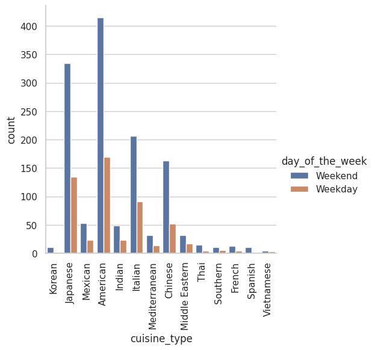

```python
plt.figure(figsize = (20, 10))
sns.catplot(df, x='cuisine_type', hue='day_of_the_week', kind='count')
plt.xticks(rotation=90)
plt.show()
```

Observations:

- the frequency distribution of weekend orders across all cuisines follows a similar pattern to the distribution of weekday orders across all cuisines

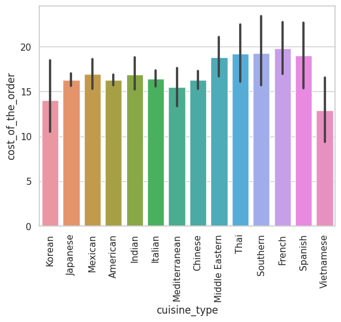

```python
sns.barplot(df, x='cuisine_type', y='cost_of_the_order')
plt.xticks(rotation=90)
plt.show()
```

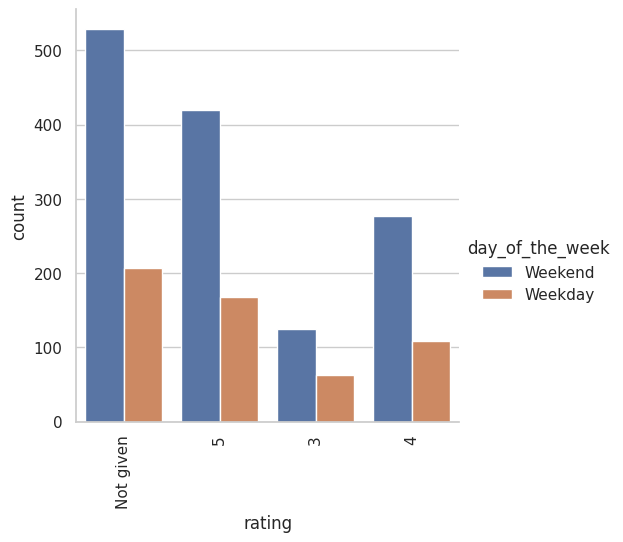

```python
sns.catplot(df, x='rating', hue='day_of_the_week',kind='count')
plt.xticks(rotation=90)
plt.show()
```

Observations:

- most ratings are given on weekends

Observations:

- vietnamese and Korean cuisine are two of the cheapest cuisines on average, although there is quite large variability around the measured mean
- French, Souther, Spanish, and Thai food are on average the most expensive with a relatively large degree of variablility around these average cost estimates
- Japanese, American, Italian, and Chinese cuisines are similarly priced. There is also not a lot of variability around the these average cost estimates

### **Question 13:** The company wants to provide a promotional offer in the advertisement of the restaurants. The condition to get the offer is that the restaurants must have a rating count of more than 50 and the average rating should be greater than 4. Find the restaurants fulfilling the criteria to get the promotional offer. [3 marks]

```python
# Replace 'Not given' with NaN
df['rating'] = df['rating'].replace('Not given', np.nan)

# Remove records with na ratings
df_rated = df.dropna()

# Convert the 'rating' column to integers (after handling missing values)
df['rating'] = df['rating'].astype(float).dropna().astype(int)



# Calculate the count of ratings for each restaurant
restaurant_rating_count = df.groupby(['restaurant_name'])['rating'].count()

# Calculate the average rating for each restaurant
restaurant_avg_rating = df.groupby(['restaurant_name'])['rating'].mean()

# Filter restaurants with more than 50 ratings and an average rating greater than 4
selected_restaurants = restaurant_rating_count[(restaurant_rating_count > 50) & (restaurant_avg_rating > 4)]

# Print the selected restaurants
print("Restaurants with more than 50 ratings and an average rating greater than 4:")
print(selected_restaurants)
```

```
Restaurants with more than 50 ratings and an average rating greater than 4:
restaurant_name
Blue Ribbon Fried Chicken     64
Blue Ribbon Sushi             73
Shake Shack                  133
The Meatball Shop             84
Name: rating, dtype: int64
```

### **Question 14:** The company charges the restaurant 25% on the orders having cost greater than 20 dollars and 15% on the orders having cost greater than 5 dollars. Find the net revenue generated by the company across all orders. [3 marks]

```python
# Calculate net revenue based on the provided charges
for index, row in df.iterrows():
    cost = row['cost_of_the_order']

    if cost > 20:
        net_revenue = cost * 0.25  # 25% charge
    elif cost > 5:
        net_revenue = cost * 0.15  # 15% charge
    else:
        net_revenue = cost * 0.00 # No charge

    df.at[index, 'net_revenue'] = net_revenue

# Calculate the total net revenue across all orders
total_net_revenue = df['net_revenue'].sum()

print(f"Total net revenue generated by the company: ${total_net_revenue:.2f}")
```

```
Total net revenue generated by the company: $6166.30
```

```python
# Calculate net revenue based on the provided charges using vectorized operations
df['net_revenue'] = df['cost_of_the_order'].apply(
    lambda cost: cost * 0.25 if cost > 20 else (cost * 0.15 if cost > 5 else cost * 0.00)
)

# Calculate the total net revenue across all orders
total_net_revenue = df['net_revenue'].sum()

print(f"Total net revenue generated by the company: ${total_net_revenue:.2f}")
```

```
Total net revenue generated by the company: $6166.30
```

#### Observations:

Total net revenue generated by the company: $6166.30

### **Question 15:** The company wants to analyze the total time required to deliver the food. What percentage of orders take more than 60 minutes to get delivered from the time the order is placed? (The food has to be prepared and then delivered.) [2 marks]

```python
# Calculate the total time required for each order (food preparation time + delivery time)
df['total_time'] = df['food_preparation_time'] + df['delivery_time']

# Calculate the percentage of orders that take more than 60 minutes
orders_above_60_minutes = df[df['total_time'] > 60]
percentage_above_60_minutes = (len(orders_above_60_minutes) / len(df)) * 100

print(f"Percentage of orders taking more than 60 minutes: {percentage_above_60_minutes:.2f}%")
```

```
Percentage of orders taking more than 60 minutes: 10.54%
```

#### Observations:

Percentage of orders taking more than 60 minutes: 10.54%

### **Question 16:** The company wants to analyze the delivery time of the orders on weekdays and weekends. How does the mean delivery time vary during weekdays and weekends? [2 marks]

```python
# Calculate the average delivery time during the week and weekends
avg_delivery_time = df.groupby('day_of_the_week')['delivery_time'].mean().reset_index()
avg_delivery_time.columns = ['Week/Weekend', 'Average Delivery Time']

print(avg_delivery_time)
```

```
  Week/Weekend  Average Delivery Time
0      Weekday              28.340037
1      Weekend              22.470022
```

#### Observations:

- the average delivery time during the week is approx. 28 minutes
- the average delivery time on weekends is approx 22 mins